# Data Wrangling Project: Investigate WeRateDogs Twitter data

- Introduction
- Data Wrangling
- Gathering data
- Assessing data
- Cleaning data
- Storing, Analyzing and Visualizing data
- Conclusions

## Introduction

In this project we will be wrangling the WeRateDogs Twitter data. We will be gathering the data from different source files andn load them in the jupyter notebook. The data is then assessed, we are looking for quality and tidiness issues. We will then clean those issues and merge the different sources into one dataframe to be stored and analyzed. The analysis will show three types of insight from this dataset on rating dogs from twitter.

```python
#loading libraries and defining plots settings
import pandas as pd
import numpy as np
import matplotlib
matplotlib.rcParams.update({'font.size': 16})
import matplotlib.pyplot as plt
import pickle
import twitter
import requests
import io
import PIL
```

## Data Wrangling

### Gather data

```python
#Load data into pandas dataframes
tweet_csv=pd.read_csv('twitter-archive-enhanced.csv')
tweet_json=pd.read_json('tweet.json',lines=True)
preds=pd.read_csv('image-predictions.tsv',sep='\t')
'''Twitter=pickle.load(open('secret_twitter_credentials.pkl','rb'))
auth = twitter.oauth.OAuth(Twitter['Access Token'],Twitter['Access Token Secret'],Twitter['Consumer Key'],Twitter['Consumer Secret'])
twitter_api = twitter.Twitter(auth=auth)
local_trends = twitter_api.trends.place(_id=560472)
local_trends[0]['trends']'''
```

```
"Twitter=pickle.load(open('secret_twitter_credentials.pkl','rb'))\nauth = twitter.oauth.OAuth(Twitter['Access Token'],Twitter['Access Token Secret'],Twitter['Consumer Key'],Twitter['Consumer Secret'])\ntwitter_api = twitter.Twitter(auth=auth)\nlocal_trends = twitter_api.trends.place(_id=560472)\nloc…
```

### Assessing data:

```python
# visually and programmatically explore the data
#Archive tweet csv data
print(tweet_csv.info())
print()
print('Number of duplicated rows: {}'.format(tweet_csv.duplicated().sum()))
tweet_csv#.head()
```

```
<class 'pandas.core.frame.DataFrame'>
RangeIndex: 2356 entries, 0 to 2355
Data columns (total 17 columns):
 #   Column                      Non-Null Count  Dtype
---  ------                      --------------  -----
 0   tweet_id                    2356 non-null   int64
 1   in_reply_to_status_id       78 non-null     float64
 2   in_reply_to_user_id         78 non-null     float64
 3   timestamp                   2356 non-null   object
 4   source                      2356 non-null   object
 5   text                        2356 non-null   object
 6   retweeted_status_id         181 non-null    float64
 7   retweeted_status_user_id    181 non-null    float64
 8   retweeted_status_timestamp  181 non-null    object
 9   expanded_urls               2297 non-null   object
 10  rating_numerator            2356 non-null   int64
 11  rating_denominator          2356 non-null   int64
 12  name                        2356 non-null   object
 13  doggo                       2356 non-null   object
 14  floofer                     2356 non-null   object
 15  pupper                      2356 non-null   object
 16  puppo                       2356 non-null   object
dtypes: float64(4), int64(3), object(10)
memory usage: 313.0+ KB
None

Number of duplicated rows: 0
```

|  | tweet_id | in_reply_to_status_id | in_reply_to_user_id | timestamp | source | text | retweeted_status_id | retweeted_status_user_id | retweeted_status_timestamp | expanded_urls | rating_numerator | rating_denominator | name | doggo | floofer | pupper | puppo |
| --- | --- | --- | --- | --- | --- | --- | --- | --- | --- | --- | --- | --- | --- | --- | --- | --- | --- |
| 0 | 892420643555336193 | NaN | NaN | 2017-08-01 16:23:56 +0000 | <a href="http://twitter.com/download/iphone" r... | This is Phineas. He's a mystical boy. Only eve... | NaN | NaN | NaN | https://twitter.com/dog_rates/status/892420643... | 13 | 10 | Phineas | None | None | None | None |
| 1 | 892177421306343426 | NaN | NaN | 2017-08-01 00:17:27 +0000 | <a href="http://twitter.com/download/iphone" r... | This is Tilly. She's just checking pup on you.... | NaN | NaN | NaN | https://twitter.com/dog_rates/status/892177421... | 13 | 10 | Tilly | None | None | None | None |
| 2 | 891815181378084864 | NaN | NaN | 2017-07-31 00:18:03 +0000 | <a href="http://twitter.com/download/iphone" r... | This is Archie. He is a rare Norwegian Pouncin... | NaN | NaN | NaN | https://twitter.com/dog_rates/status/891815181... | 12 | 10 | Archie | None | None | None | None |
| 3 | 891689557279858688 | NaN | NaN | 2017-07-30 15:58:51 +0000 | <a href="http://twitter.com/download/iphone" r... | This is Darla. She commenced a snooze mid meal... | NaN | NaN | NaN | https://twitter.com/dog_rates/status/891689557... | 13 | 10 | Darla | None | None | None | None |
| 4 | 891327558926688256 | NaN | NaN | 2017-07-29 16:00:24 +0000 | <a href="http://twitter.com/download/iphone" r... | This is Franklin. He would like you to stop ca... | NaN | NaN | NaN | https://twitter.com/dog_rates/status/891327558... | 12 | 10 | Franklin | None | None | None | None |
| ... | ... | ... | ... | ... | ... | ... | ... | ... | ... | ... | ... | ... | ... | ... | ... | ... | ... |
| 2351 | 666049248165822465 | NaN | NaN | 2015-11-16 00:24:50 +0000 | <a href="http://twitter.com/download/iphone" r... | Here we have a 1949 1st generation vulpix. Enj... | NaN | NaN | NaN | https://twitter.com/dog_rates/status/666049248... | 5 | 10 | None | None | None | None | None |
| 2352 | 666044226329800704 | NaN | NaN | 2015-11-16 00:04:52 +0000 | <a href="http://twitter.com/download/iphone" r... | This is a purebred Piers Morgan. Loves to Netf... | NaN | NaN | NaN | https://twitter.com/dog_rates/status/666044226... | 6 | 10 | a | None | None | None | None |
| 2353 | 666033412701032449 | NaN | NaN | 2015-11-15 23:21:54 +0000 | <a href="http://twitter.com/download/iphone" r... | Here is a very happy pup. Big fan of well-main... | NaN | NaN | NaN | https://twitter.com/dog_rates/status/666033412... | 9 | 10 | a | None | None | None | None |
| 2354 | 666029285002620928 | NaN | NaN | 2015-11-15 23:05:30 +0000 | <a href="http://twitter.com/download/iphone" r... | This is a western brown Mitsubishi terrier. Up... | NaN | NaN | NaN | https://twitter.com/dog_rates/status/666029285... | 7 | 10 | a | None | None | None | None |
| 2355 | 666020888022790149 | NaN | NaN | 2015-11-15 22:32:08 +0000 | <a href="http://twitter.com/download/iphone" r... | Here we have a Japanese Irish Setter. Lost eye... | NaN | NaN | NaN | https://twitter.com/dog_rates/status/666020888... | 8 | 10 | None | None | None | None | None |

2356 rows × 17 columns

```
The number of unique tweet id is 2356 and the length of the dataframe is 2356.
Distribution of numerator and denominator in rating:
```

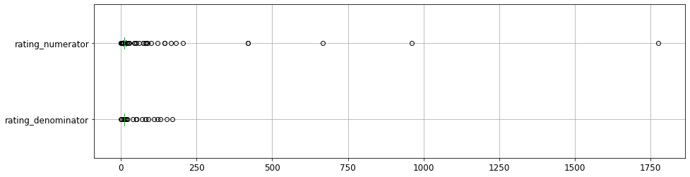

```
      rating_denominator  rating_numerator
784                   11                 9
1068                  11                 9
1662                  11                 7
342                   15                11
1663                  16                20
1165                  20                 4
1598                  20                 4
1433                  40                44
1202                  50                50
1274                  50                45
1351                  50                60
433                   70                84
1254                  80                80
1843                  80                88
1228                  90                99
1635                 110               121
1779                 120               144
1634                 130               143
902                  150               165
1120                 170               204

[None        745
a            55
Charlie      12
Lucy         11
Cooper       11
           ...
Terrenth      1
Dug           1
Pip           1
Diogi         1
BeBe          1
Name: name, Length: 957, dtype: int64, None     2259
doggo      97
Name: doggo, dtype: int64, None       2346
floofer      10
Name: floofer, dtype: int64, None      2099
pupper     257
Name: pupper, dtype: int64, None     2326
puppo      30
Name: puppo, dtype: int64]
```

```python
print('The number of unique tweet id is {} and the length of the dataframe is {}.'.format(len(tweet_csv.tweet_id.unique()),tweet_csv.shape[0]))
print('Distribution of numerator and denominator in rating:')
tweet_csv[['rating_denominator','rating_numerator']].boxplot(vert=False,figsize=(15,4),fontsize=12)
plt.show()
print(tweet_csv.loc[tweet_csv.rating_denominator>10,['rating_denominator','rating_numerator']].sort_values(by='rating_denominator'))
print()
print([tweet_csv[col].value_counts() for col in tweet_csv.columns[-5:]])
```

**Observations:**

**Quality:**

- "None" values in the last columns are not captured as missing data
- the rating_denominator is showing values greater than 10
- the column with dogs' names presents 55 times the name 'a' which seems to be a mistake

**Tidiness:**

- the variables: "in_reply_to_status_id", "in_reply_to_user_id", "retweeted_status_id" and "retweeted_status_user_id" are showing a float type instead of integer
- the variables: "timestamp" and "retweeted_status_timestamp" show an object type instead of datetime

```python
# new tweet data from json file
tweet_json.info()
tweet_json#.head()
```

```
<class 'pandas.core.frame.DataFrame'>
RangeIndex: 2354 entries, 0 to 2353
Data columns (total 31 columns):
 #   Column                         Non-Null Count  Dtype
---  ------                         --------------  -----
 0   created_at                     2354 non-null   datetime64[ns, UTC]
 1   id                             2354 non-null   int64
 2   id_str                         2354 non-null   int64
 3   full_text                      2354 non-null   object
 4   truncated                      2354 non-null   bool
 5   display_text_range             2354 non-null   object
 6   entities                       2354 non-null   object
 7   extended_entities              2073 non-null   object
 8   source                         2354 non-null   object
 9   in_reply_to_status_id          78 non-null     float64
```

[output cut: 23 more lines]

|  | created_at | id | id_str | full_text | truncated | display_text_range | entities | extended_entities | source | in_reply_to_status_id | ... | favorite_count | favorited | retweeted | possibly_sensitive | possibly_sensitive_appealable | lang | retweeted_status | quoted_status_id | quoted_status_id_str | quoted_status |
| --- | --- | --- | --- | --- | --- | --- | --- | --- | --- | --- | --- | --- | --- | --- | --- | --- | --- | --- | --- | --- | --- |
| 0 | 2017-08-01 16:23:56+00:00 | 892420643555336193 | 892420643555336192 | This is Phineas. He's a mystical boy. Only eve... | False | [0, 85] | {'hashtags': [], 'symbols': [], 'user_mentions... | {'media': [{'id': 892420639486877696, 'id_str'... | <a href="http://twitter.com/download/iphone" r... | NaN | ... | 39467 | False | False | 0.0 | 0.0 | en | NaN | NaN | NaN | NaN |
| 1 | 2017-08-01 00:17:27+00:00 | 892177421306343426 | 892177421306343424 | This is Tilly. She's just checking pup on you.... | False | [0, 138] | {'hashtags': [], 'symbols': [], 'user_mentions... | {'media': [{'id': 892177413194625024, 'id_str'... | <a href="http://twitter.com/download/iphone" r... | NaN | ... | 33819 | False | False | 0.0 | 0.0 | en | NaN | NaN | NaN | NaN |
| 2 | 2017-07-31 00:18:03+00:00 | 891815181378084864 | 891815181378084864 | This is Archie. He is a rare Norwegian Pouncin... | False | [0, 121] | {'hashtags': [], 'symbols': [], 'user_mentions... | {'media': [{'id': 891815175371796480, 'id_str'... | <a href="http://twitter.com/download/iphone" r... | NaN | ... | 25461 | False | False | 0.0 | 0.0 | en | NaN | NaN | NaN | NaN |
| 3 | 2017-07-30 15:58:51+00:00 | 891689557279858688 | 891689557279858688 | This is Darla. She commenced a snooze mid meal... | False | [0, 79] | {'hashtags': [], 'symbols': [], 'user_mentions... | {'media': [{'id': 891689552724799489, 'id_str'... | <a href="http://twitter.com/download/iphone" r... | NaN | ... | 42908 | False | False | 0.0 | 0.0 | en | NaN | NaN | NaN | NaN |
| 4 | 2017-07-29 16:00:24+00:00 | 891327558926688256 | 891327558926688256 | This is Franklin. He would like you to stop ca... | False | [0, 138] | {'hashtags': [{'text': 'BarkWeek', 'indices': ... | {'media': [{'id': 891327551943041024, 'id_str'... | <a href="http://twitter.com/download/iphone" r... | NaN | ... | 41048 | False | False | 0.0 | 0.0 | en | NaN | NaN | NaN | NaN |
| ... | ... | ... | ... | ... | ... | ... | ... | ... | ... | ... | ... | ... | ... | ... | ... | ... | ... | ... | ... | ... | ... |
| 2349 | 2015-11-16 00:24:50+00:00 | 666049248165822465 | 666049248165822464 | Here we have a 1949 1st generation vulpix. Enj... | False | [0, 120] | {'hashtags': [], 'symbols': [], 'user_mentions... | {'media': [{'id': 666049244999131136, 'id_str'... | <a href="http://twitter.com/download/iphone" r... | NaN | ... | 111 | False | False | 0.0 | 0.0 | en | NaN | NaN | NaN | NaN |
| 2350 | 2015-11-16 00:04:52+00:00 | 666044226329800704 | 666044226329800704 | This is a purebred Piers Morgan. Loves to Netf... | False | [0, 137] | {'hashtags': [], 'symbols': [], 'user_mentions... | {'media': [{'id': 666044217047650304, 'id_str'... | <a href="http://twitter.com/download/iphone" r... | NaN | ... | 311 | False | False | 0.0 | 0.0 | en | NaN | NaN | NaN | NaN |
| 2351 | 2015-11-15 23:21:54+00:00 | 666033412701032449 | 666033412701032448 | Here is a very happy pup. Big fan of well-main... | False | [0, 130] | {'hashtags': [], 'symbols': [], 'user_mentions... | {'media': [{'id': 666033409081393153, 'id_str'... | <a href="http://twitter.com/download/iphone" r... | NaN | ... | 128 | False | False | 0.0 | 0.0 | en | NaN | NaN | NaN | NaN |
| 2352 | 2015-11-15 23:05:30+00:00 | 666029285002620928 | 666029285002620928 | This is a western brown Mitsubishi terrier. Up... | False | [0, 139] | {'hashtags': [], 'symbols': [], 'user_mentions... | {'media': [{'id': 666029276303482880, 'id_str'... | <a href="http://twitter.com/download/iphone" r... | NaN | ... | 132 | False | False | 0.0 | 0.0 | en | NaN | NaN | NaN | NaN |
| 2353 | 2015-11-15 22:32:08+00:00 | 666020888022790149 | 666020888022790144 | Here we have a Japanese Irish Setter. Lost eye... | False | [0, 131] | {'hashtags': [], 'symbols': [], 'user_mentions... | {'media': [{'id': 666020881337073664, 'id_str'... | <a href="http://twitter.com/download/iphone" r... | NaN | ... | 2535 | False | False | 0.0 | 0.0 | en | NaN | NaN | NaN | NaN |

2354 rows × 31 columns

```python
cols=[col for col in tweet_json if 'id' in col]
for i in range(0,len(cols),2):
    print(cols[i:i+2])
    print(tweet_json.loc[:,cols[i:i+2]].duplicated().sum())
print(tweet_json.shape[0])
```

```
['id', 'id_str']
0
['in_reply_to_status_id', 'in_reply_to_status_id_str']
2276
['in_reply_to_user_id', 'in_reply_to_user_id_str']
2322
['quoted_status_id', 'quoted_status_id_str']
2324
2354
```

**Observations:** **Quality:**

- the variables: "geo", "coordinate" and "contributors" do not contain any value other than nan
- the variable "place" contains only one non-missing value
- the variables "retweeted_status" and "quoted_status" contain 179, and respectively 28, non-missing value. Each one being a dictionary with the fields in dataframe tweet_json from column "created_at" to "lang"

**Tidiness:**

- the variables: "in_reply_to_status_id", "in_reply_to_user_id", "in_reply_to_status_id_str", "in_reply_to_user_id_str","quoted_status_id" and "quoted_status_id_str" are showing a float type instead of integer

```python
# images prediction
preds.info()
preds#.head()
```

```
<class 'pandas.core.frame.DataFrame'>
RangeIndex: 2075 entries, 0 to 2074
Data columns (total 12 columns):
 #   Column    Non-Null Count  Dtype
---  ------    --------------  -----
 0   tweet_id  2075 non-null   int64
 1   jpg_url   2075 non-null   object
 2   img_num   2075 non-null   int64
 3   p1        2075 non-null   object
 4   p1_conf   2075 non-null   float64
 5   p1_dog    2075 non-null   bool
 6   p2        2075 non-null   object
 7   p2_conf   2075 non-null   float64
 8   p2_dog    2075 non-null   bool
 9   p3        2075 non-null   object
 10  p3_conf   2075 non-null   float64
 11  p3_dog    2075 non-null   bool
dtypes: bool(3), float64(3), int64(2), object(4)
memory usage: 152.1+ KB
```

|  | tweet_id | jpg_url | img_num | p1 | p1_conf | p1_dog | p2 | p2_conf | p2_dog | p3 | p3_conf | p3_dog |
| --- | --- | --- | --- | --- | --- | --- | --- | --- | --- | --- | --- | --- |
| 0 | 666020888022790149 | https://pbs.twimg.com/media/CT4udn0WwAA0aMy.jpg | 1 | Welsh_springer_spaniel | 0.465074 | True | collie | 0.156665 | True | Shetland_sheepdog | 0.061428 | True |
| 1 | 666029285002620928 | https://pbs.twimg.com/media/CT42GRgUYAA5iDo.jpg | 1 | redbone | 0.506826 | True | miniature_pinscher | 0.074192 | True | Rhodesian_ridgeback | 0.072010 | True |
| 2 | 666033412701032449 | https://pbs.twimg.com/media/CT4521TWwAEvMyu.jpg | 1 | German_shepherd | 0.596461 | True | malinois | 0.138584 | True | bloodhound | 0.116197 | True |
| 3 | 666044226329800704 | https://pbs.twimg.com/media/CT5Dr8HUEAA-lEu.jpg | 1 | Rhodesian_ridgeback | 0.408143 | True | redbone | 0.360687 | True | miniature_pinscher | 0.222752 | True |
| 4 | 666049248165822465 | https://pbs.twimg.com/media/CT5IQmsXIAAKY4A.jpg | 1 | miniature_pinscher | 0.560311 | True | Rottweiler | 0.243682 | True | Doberman | 0.154629 | True |
| ... | ... | ... | ... | ... | ... | ... | ... | ... | ... | ... | ... | ... |
| 2070 | 891327558926688256 | https://pbs.twimg.com/media/DF6hr6BUMAAzZgT.jpg | 2 | basset | 0.555712 | True | English_springer | 0.225770 | True | German_short-haired_pointer | 0.175219 | True |
| 2071 | 891689557279858688 | https://pbs.twimg.com/media/DF_q7IAWsAEuuN8.jpg | 1 | paper_towel | 0.170278 | False | Labrador_retriever | 0.168086 | True | spatula | 0.040836 | False |
| 2072 | 891815181378084864 | https://pbs.twimg.com/media/DGBdLU1WsAANxJ9.jpg | 1 | Chihuahua | 0.716012 | True | malamute | 0.078253 | True | kelpie | 0.031379 | True |
| 2073 | 892177421306343426 | https://pbs.twimg.com/media/DGGmoV4XsAAUL6n.jpg | 1 | Chihuahua | 0.323581 | True | Pekinese | 0.090647 | True | papillon | 0.068957 | True |
| 2074 | 892420643555336193 | https://pbs.twimg.com/media/DGKD1-bXoAAIAUK.jpg | 1 | orange | 0.097049 | False | bagel | 0.085851 | False | banana | 0.076110 | False |

2075 rows × 12 columns

**Observations:** The dataset looks clean and tidy. There is no missing data.

### Cleaning Data

```python
#copy tweet csv data to new dataframe and clean
#replace None with nan
tweet_csv_new=tweet_csv.replace('None',np.nan)
#keep only rows for which rating_denominator is lesser or equal to 10
tweet_csv_new=tweet_csv_new.loc[tweet_csv_new.rating_denominator<=10,:]
#replace the dogs' names 'a' with nan
tweet_csv_new.loc[tweet_csv_new.name=='a',['name']]=np.nan
#change type to integer for: "in_reply_to_status_id", "in_reply_to_user_id", "retweeted_status_id" and "retweeted_status_user_id"
cols=['in_reply_to_status_id', 'in_reply_to_user_id', 'retweeted_status_id','retweeted_status_user_id']
tweet_csv_new.loc[:,cols]=tweet_csv_new.loc[:,cols].astype('Int64')
#change type to datetime for: "timestamp" and "retweeted_status_timestamp"
cols=['timestamp','retweeted_status_timestamp']
tweet_csv_new.loc[:,cols]=tweet_csv_new.loc[:,cols].astype('datetime64')

#display updated info on the dataframe
tweet_csv_new.info()
```

```
<class 'pandas.core.frame.DataFrame'>
Int64Index: 2336 entries, 0 to 2355
Data columns (total 17 columns):
 #   Column                      Non-Null Count  Dtype
---  ------                      --------------  -----
 0   tweet_id                    2336 non-null   int64
 1   in_reply_to_status_id       74 non-null     Int64
 2   in_reply_to_user_id         74 non-null     Int64
 3   timestamp                   2336 non-null   datetime64[ns]
 4   source                      2336 non-null   object
 5   text                        2336 non-null   object
 6   retweeted_status_id         180 non-null    Int64
 7   retweeted_status_user_id    180 non-null    Int64
 8   retweeted_status_timestamp  180 non-null    datetime64[ns]
 9   expanded_urls               2280 non-null   object
 10  rating_numerator            2336 non-null   int64
 11  rating_denominator          2336 non-null   int64
 12  name                        1553 non-null   object
 13  doggo                       97 non-null     object
 14  floofer                     10 non-null     object
 15  pupper                      257 non-null    object
 16  puppo                       30 non-null     object
dtypes: Int64(4), datetime64[ns](2), int64(3), object(8)
memory usage: 337.6+ KB
```

```python
#copy tweet json data to new dataframe and clean
#drop columns "geo", "coordinates" and "contributors" which do not contain any value other than nan
tweet_json_new=tweet_json.drop(columns=["geo", "coordinates", "contributors"])
#drop the variable "place" which contains only one non-missing value
tweet_json_new=tweet_json_new.drop(columns=["place"])
#drop the columns "retweeted_status" and "quoted_status" as they present less than 10% of non-missing data
tweet_json_new=tweet_json_new.drop(columns=["retweeted_status","quoted_status"])
#change type to integer for: "in_reply_to_status_id", "in_reply_to_user_id", "in_reply_to_status_id_str", "in_reply_to_user_id_str","quoted_status_id" and "quoted_status_id_str"
cols=["in_reply_to_status_id", "in_reply_to_user_id", "in_reply_to_status_id_str", "in_reply_to_user_id_str","quoted_status_id" , "quoted_status_id_str"]
tweet_json_new.loc[:,cols]=tweet_json_new.loc[:,cols].astype('Int64')

#display updated info on the dataframe
tweet_json_new.info()
```

```
<class 'pandas.core.frame.DataFrame'>
RangeIndex: 2354 entries, 0 to 2353
Data columns (total 25 columns):
 #   Column                         Non-Null Count  Dtype
---  ------                         --------------  -----
 0   created_at                     2354 non-null   datetime64[ns, UTC]
 1   id                             2354 non-null   int64
 2   id_str                         2354 non-null   int64
 3   full_text                      2354 non-null   object
 4   truncated                      2354 non-null   bool
 5   display_text_range             2354 non-null   object
 6   entities                       2354 non-null   object
 7   extended_entities              2073 non-null   object
 8   source                         2354 non-null   object
 9   in_reply_to_status_id          78 non-null     Int64
```

[output cut: 17 more lines]

```python
print(tweet_json_new.loc[:,['id','id_str']].head())
```

```
                   id              id_str
0  892420643555336193  892420643555336192
1  892177421306343426  892177421306343424
2  891815181378084864  891815181378084864
3  891689557279858688  891689557279858688
4  891327558926688256  891327558926688256
```

```python
#Merge all three cleaned data sets into one
#merge tweet_csv_new and tweet_json_new
DF=tweet_csv_new.merge(tweet_json_new, left_on='tweet_id', right_on='id',how='outer',suffixes=('_csv','_json'),sort=1)
DF.loc[:,['tweet_id','id','id_str']]=DF.loc[:,['tweet_id','id','id_str']].astype('Int64')
#DF.info()
#print()
#merge with remaining dataframe: image preds
preds['tweet_id']=preds['tweet_id'].astype('Int64')
DF=DF.merge(preds, on='tweet_id',how='outer',suffixes=('_main','_preds'),sort=1)
DF.info()
```

```
<class 'pandas.core.frame.DataFrame'>
Int64Index: 3090 entries, 0 to 3089
Data columns (total 53 columns):
 #   Column                         Non-Null Count  Dtype
---  ------                         --------------  -----
 0   tweet_id                       3070 non-null   object
 1   in_reply_to_status_id_csv      74 non-null     Int64
 2   in_reply_to_user_id_csv        74 non-null     Int64
 3   timestamp                      2336 non-null   datetime64[ns]
 4   source_csv                     2336 non-null   object
 5   text                           2336 non-null   object
 6   retweeted_status_id            180 non-null    Int64
 7   retweeted_status_user_id       180 non-null    Int64
 8   retweeted_status_timestamp     180 non-null    datetime64[ns]
 9   expanded_urls                  2280 non-null   object
```

[output cut: 45 more lines]

## Storing, Analyzing and Visualizing

### Store the gathered, assessed, and cleaned dataset

```python
DF.to_csv('master_dataset.csv')
```

### Insight #1: What is the distribution of ratings? Which dog scored the highest rating?

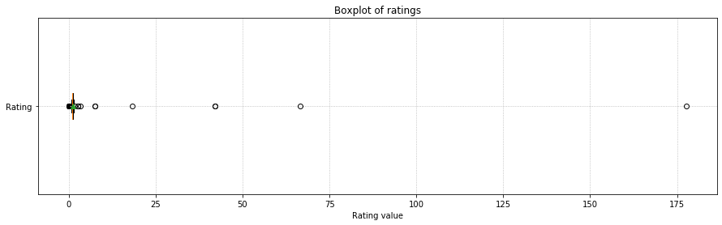

```
The average value is: 1.2 and the maximum: 177.6
```

```python
#Compute rating: numerator/denominator
DF['rating']=DF.rating_numerator/DF.rating_denominator
DF.loc[DF.rating_denominator==0,'rating']=np.nan
#plot distribution
plt.figure(figsize=(15,4))
plt.boxplot(DF.rating[DF.rating.notnull()],vert=0,showmeans=1)
plt.grid(linestyle=':')
plt.title('Boxplot of ratings')
plt.yticks([1],['Rating'])
plt.xlabel('Rating value')
plt.show()
print('The average value is: {} and the maximum: {}'.format(round(DF.rating.mean(),1),round(DF.rating.max(),1)))
```

```
Atticus shows the highest rating of: 177.6
```

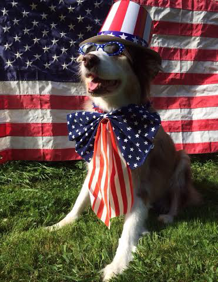

```python
info=DF.loc[DF.rating==DF.rating.max(),['name','jpg_url']].values
response = requests.get(info[0][1])
image_bytes = io.BytesIO(response.content)
print('{} shows the highest rating of: {}'.format(info[0][0],DF.rating.max()))
PIL.Image.open(image_bytes)
```

### Insight #2: What are the types of dogs with highest ratings?

```python
#Create a sub dataset from DF with only the columns of interest for this analysis and remove rows with missing data
DF_sub=DF.loc[:,['rating','p1','p1_conf']].sort_values(by='rating',ascending=0)
DF_sub=DF_sub.dropna()
# the type of dog is extracted from the predictions p1, we select only the types that appear more than 5 times to make sure to have real dog's breeds
dog_types=list(DF_sub['p1'].value_counts()[DF_sub['p1'].value_counts()>5].index)
#group the sub dataset by dog's breed and sort by average rating for a breed only when the confidence of forecast of the breed is higher than 0.5
DF_sub.loc[(DF_sub.p1.isin(dog_types))&(DF_sub.p1_conf>.5)].groupby('p1').mean()['rating'].sort_values(ascending=False).head(10)
```

```
p1
Siberian_husky          1.220000
miniature_poodle        1.200000
Norfolk_terrier         1.200000
basset                  1.200000
golden_retriever        1.186535
Old_English_sheepdog    1.183333
Norwegian_elkhound      1.175000
Eskimo_dog              1.171429
tennis_ball             1.160000
Cardigan                1.160000
Name: rating, dtype: float64
```

**The Siberian husky is the dogs' breed showing the highest rating with an average of 1.22 for this group. It is followed closely by the miniature poodle, Norfolk terrier and basset with an average rating of 1.2**

### Insight #3: Which tweet has shown the highest number of re-tweets? and highest number of favorites?

```python
#DF.loc[DF.retweet_count==DF.retweet_count.max()].values
print('Tweet with highest number of retweet: ')
print(DF.loc[DF.retweet_count==DF.retweet_count.max(),['text']].values[0][0])
```

```
Tweet with highest number of retweet:
Here's a doggo realizing you can stand in a pool. 13/10 enlightened af (vid by Tina Conrad) https://t.co/7wE9LTEXC4
```

```
Tweet with highest number of favorite:
Here's a super supportive puppo participating in the Toronto  #WomensMarch today. 13/10 https://t.co/nTz3FtorBc
```

```python
info=DF.loc[DF.favorite_count==DF.favorite_count.max(),['text']].values[0][0]
response = requests.get('https://pbs.twimg.com/media/C2tugXLXgAArJO4?format=jpg')
image_bytes = io.BytesIO(response.content)
print('Tweet with highest number of favorite: ')
print(info)
PIL.Image.open(image_bytes)
```

[output not shown]

## Conclusions

This real dataset coming from tweet data can be very messy and dirty. A lot of work is required to tify and clean the dataset before being able to extract any valuable information from it. The project helps realizing the importance and amount of work required to clean and tidy a dataset based on non-simulated data.